# Infrastructure Development, Deforestation, and Biodiversity in India

Raahil Madhok

19 December, 2019

**What’s new here**

This document shows a series of visualizations from the eBird and deforestation data in order to decipher data trends and patterns that will guide the econometric analysis.

# 1 Deforestation and Bird-watching Activity

## 1.1 Change in Deforestation between First and Last Period

This map shows the change in cumulative deforestation (for infrastructure) between 2015 and 2018. There is ample time-series and cross-sectional variation in central, northern, and part of eastern India. These regions correspond to the regions with highest forest cover.

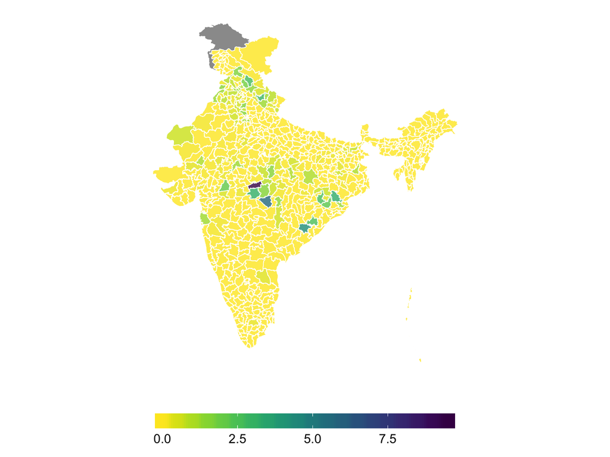

## 1.2 Birding Activity in Deforestation Districts

From panel B, there is ample variation in bird-watching activity in deforestation districts. High intensity bird-watching districts (number of trips greater than the mean) are present in all quadrants of India.

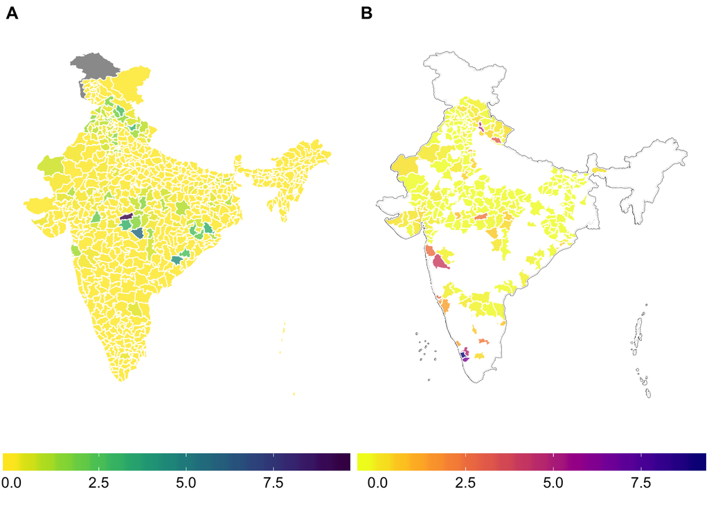

## 1.3 Spatial Coverage of Birding Activity in Deforestation Districts

The map in panel B shows the spatial coverage of bird-watching activity. This is measured by gridding the district map into 5km x 5km cells and computing the percentage of cells with at least one bird sighting. This tells us whether bird-watching is concentrated within a district or not. It is useful for capturing access, since infrastructure projects may open up access to pristine parts of the forest.

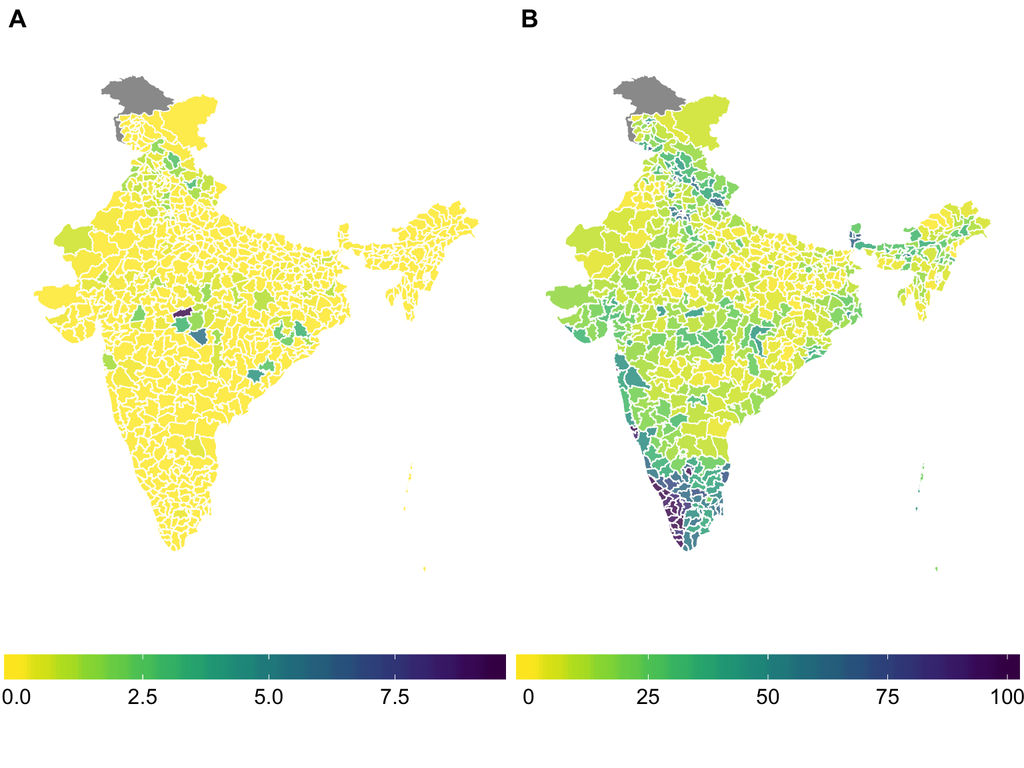

# 2 eBird Data

The final eBird data for this analysis includes 8.7 million bird sightings from 13,000 users and 680,000 trips. There is rich variation in the timing and location of these trips, so it is important to identify predictable trends in birding activity (number of trips) and species diversity that may bias the coefficients in the empirical analysis.

## 2.1 Birding Activity: Number of Trips

### 2.1.1 CDF of Number of Trips

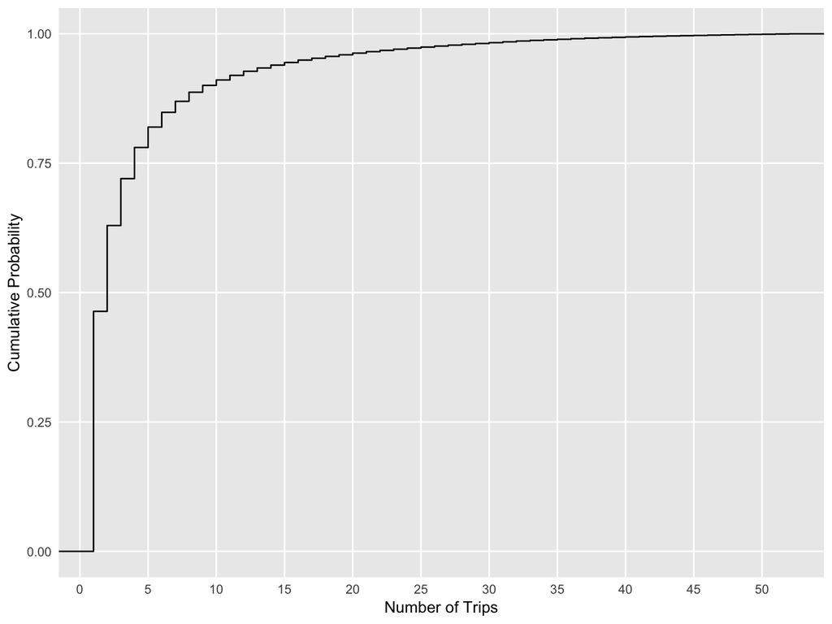

### 2.1.2 Number of Trips by Month

Bird-watching is a seasonal activity and the number of trips likely fluctuates with the weather. For example, monsoon months may see less activity because of rains and humidity. It is important to understand the seasonal dynamics of bird-watching to ensure that the coefficient estimates are not picking up seasonal trends in the dependent and independent variables.

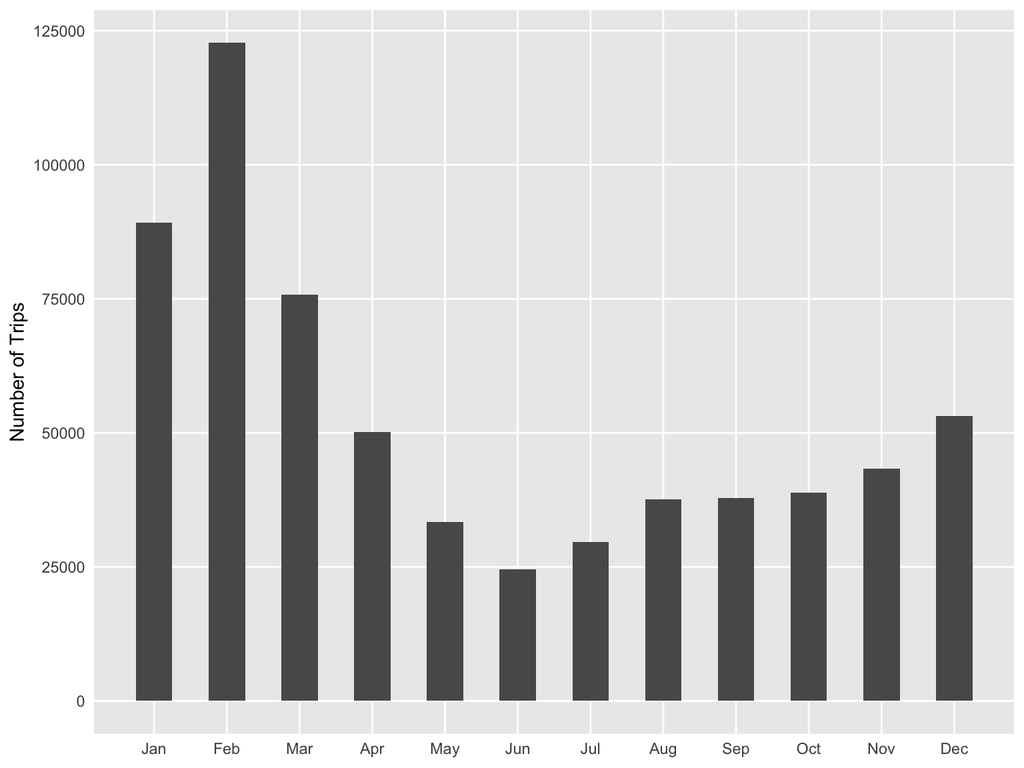

## 2.2 Seasonality of Unique Species

### 2.2.1 Unique Species Across Months of Year

The plot below shows the monthly distribution of the number of unique species for each year in the data. There is a bimodal trend for all years with peaks in the winter months and a trough in the summer. The trend is consistent with bird migration patterns. More species are observed in winter months when migratory birds from colder climates stop over in India. However, the trend may also be explained by the monthly trend in the number of trips.

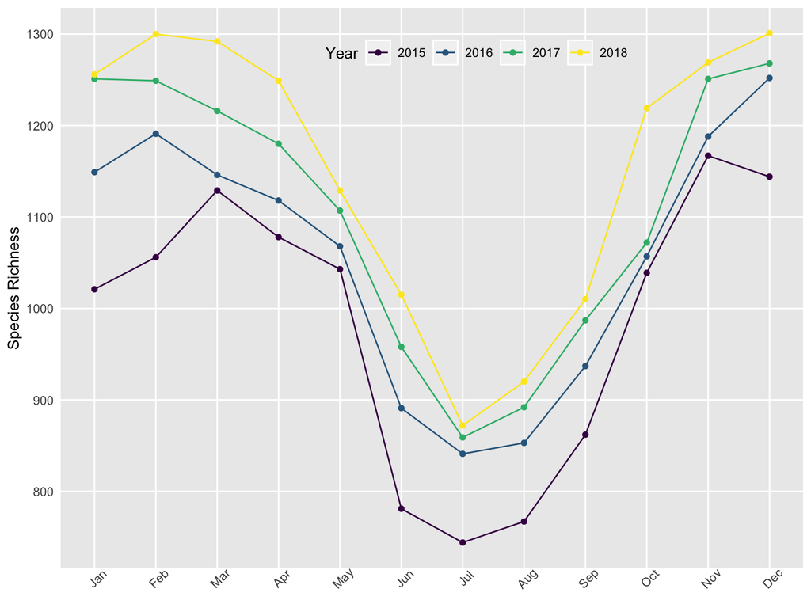

### 2.2.2 Unique Species Across Time

One characteristic of the monthly species richness distribution is that, for any given month, species richness is higher across years. This could be because of increases in overall bird migration over time (check news?). The plot below compares annual and monthly species richness. The number of unique species is consistently higher across years, and this is also true across months-of-year.

Another explanation is that increases in species diversity over time is driven by an increase in the popularity of the app.

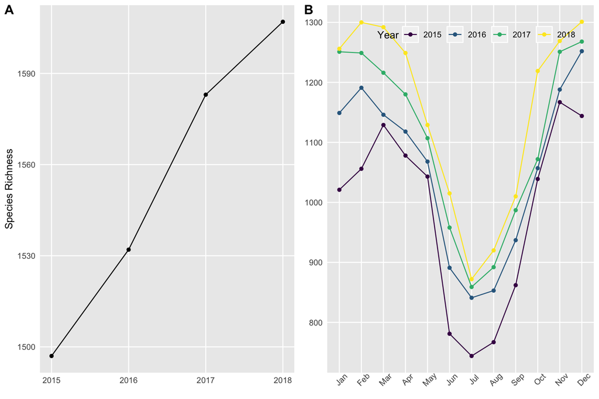

### 2.2.3 Trends in species diversity and bird-watching activity

The plot below compares seasonality of species diversity with seasonality in eBird activity. If the bars in panel B were constant, then the trend in panel A would be more likely due to bird migration patterns. However, the similar, shared distribution across months implies that variation in birding activity is partially responsible for the seasonal trend in species richness.

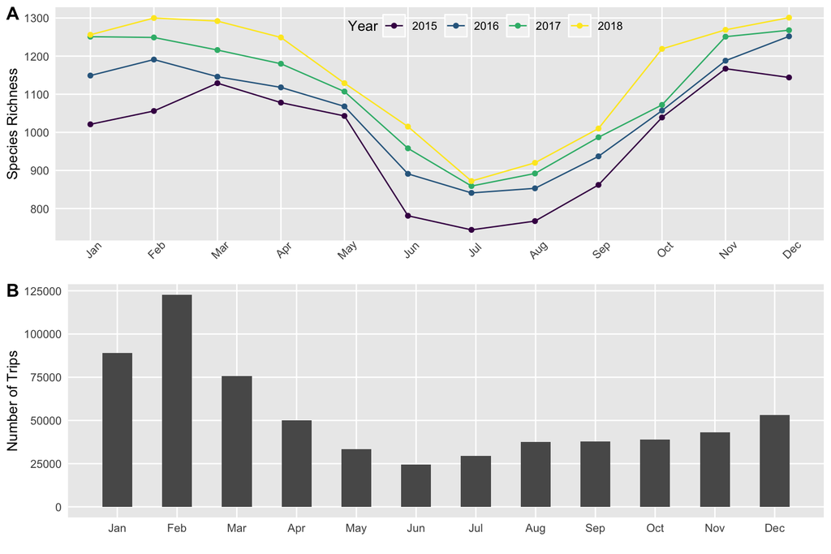

# 3 User Characteristics

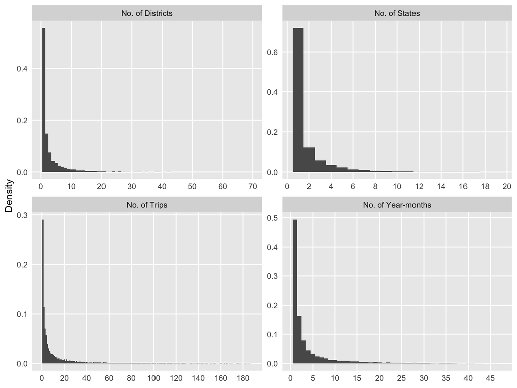